# Lab3: Extending Logistic Regression

Members:  
CSE 5324: Shenxiao Mei, Samuel Lefcourt  
CSE 7324: Chenming Cui, Zeqi Guo

## Preparation and Overview

The quality of red wine is determined by many factors. Because each red wine has components in different concentration, the red wine is likely to taste differently from brand to brand. A red wine connoisseur can usually tell the age, the quality, maybe even the name of the wine. People who know how to examine the quality of a red wine are usually considered elegant and noble. Sometimes, if people know nothing about wine, they will probably purchase red wine in bad quality for their grand event. If people just want to throw a small party, it is unwise to buy the best red wine. To solve this problem, in this lab, we will use a machine learning training model to become the wine connoisseur. We will use a dataset of red wine. This dataset is related to red variants of the Portuguese "Vinho Verde" wine. In our training process, we will classify the red wines into three quality classes: "Good", "Medium", and "Bad".

Like mentioned earlier, any party host will be interested in our results. Using our results, he/she will have freedom to choose the quality of wine for the upcoming party. Also, any wine taster will be interested in our product because it can be used to train his/her tastebuds. Most importantly, red wine manufacturers will be interested so that they can know what quality they have and know how to improve the quality by adjusting the recipe.

Our training model will mainly be deployed in real-time because the whole dataset is the same type of wine and our model is just for this specific brand. The quality or grade varies by time and storing condition.

Source: **https://www.kaggle.com/uciml/red-wine-quality-cortez-et-al-2009**

### Measure of Success

Our prediction task will be to "grade" the different red wine. Despite wine experts lauding their tastebuds and elevated senses, a study conducted by Robert Hodgson proved otherwise. He approached the organizers of the California state fair wine competition and asked them to present judges with different samples from the same bottle three times. Normally, judges scale a wine from range 50-100. He claims the results were "disturbing". After giving the judges samples from the same wine bottle, he found that they each scored it differently each time! Ranging from low 80s to high 90s, the expert judges (winemakers, sommeliers, critics and wine consultants and academics) were highly inconsistent. He further went on to say that objectively evaluating large numbers of wines as currently attempted at wine competitions is, "beyond human ability". Due to this fact that not even "experts" can consistently and accurately identify and grade wines, our goal is to reach 70% accuracy.

Source: **https://www.theguardian.com/lifeandstyle/2013/jun/23/wine-tasting-junk-science-analysis** and **https://en.wikipedia.org/wiki/Blind_wine_tasting**

```python
import pandas as pd
import numpy as np

print('Pandas:', pd.__version__)
print('Numpy:',np.__version__)

df = pd.read_csv('data/winequality-red.csv') # read in the csv file

df.info()
df.head()
df
```

```
Pandas: 0.24.0
Numpy: 1.15.4
<class 'pandas.core.frame.DataFrame'>
RangeIndex: 1599 entries, 0 to 1598
Data columns (total 12 columns):
fixed acidity           1599 non-null float64
volatile acidity        1599 non-null float64
citric acid             1599 non-null float64
residual sugar          1599 non-null float64
chlorides               1599 non-null float64
free sulfur dioxide     1599 non-null float64
total sulfur dioxide    1599 non-null float64
density                 1599 non-null float64
pH                      1599 non-null float64
sulphates               1599 non-null float64
alcohol                 1599 non-null float64
quality                 1599 non-null int64
dtypes: float64(11), int64(1)
memory usage: 150.0 KB
```

|  | fixed acidity | volatile acidity | citric acid | residual sugar | chlorides | free sulfur dioxide | total sulfur dioxide | density | pH | sulphates | alcohol | quality |
| --- | --- | --- | --- | --- | --- | --- | --- | --- | --- | --- | --- | --- |
| 0 | 7.4 | 0.700 | 0.00 | 1.9 | 0.076 | 11.0 | 34.0 | 0.99780 | 3.51 | 0.56 | 9.4 | 5 |
| 1 | 7.8 | 0.880 | 0.00 | 2.6 | 0.098 | 25.0 | 67.0 | 0.99680 | 3.20 | 0.68 | 9.8 | 5 |
| 2 | 7.8 | 0.760 | 0.04 | 2.3 | 0.092 | 15.0 | 54.0 | 0.99700 | 3.26 | 0.65 | 9.8 | 5 |
| 3 | 11.2 | 0.280 | 0.56 | 1.9 | 0.075 | 17.0 | 60.0 | 0.99800 | 3.16 | 0.58 | 9.8 | 6 |
| 4 | 7.4 | 0.700 | 0.00 | 1.9 | 0.076 | 11.0 | 34.0 | 0.99780 | 3.51 | 0.56 | 9.4 | 5 |
| 5 | 7.4 | 0.660 | 0.00 | 1.8 | 0.075 | 13.0 | 40.0 | 0.99780 | 3.51 | 0.56 | 9.4 | 5 |
| 6 | 7.9 | 0.600 | 0.06 | 1.6 | 0.069 | 15.0 | 59.0 | 0.99640 | 3.30 | 0.46 | 9.4 | 5 |
| 7 | 7.3 | 0.650 | 0.00 | 1.2 | 0.065 | 15.0 | 21.0 | 0.99460 | 3.39 | 0.47 | 10.0 | 7 |
| 8 | 7.8 | 0.580 | 0.02 | 2.0 | 0.073 | 9.0 | 18.0 | 0.99680 | 3.36 | 0.57 | 9.5 | 7 |
| 9 | 7.5 | 0.500 | 0.36 | 6.1 | 0.071 | 17.0 | 102.0 | 0.99780 | 3.35 | 0.80 | 10.5 | 5 |
| 10 | 6.7 | 0.580 | 0.08 | 1.8 | 0.097 | 15.0 | 65.0 | 0.99590 | 3.28 | 0.54 | 9.2 | 5 |
| 11 | 7.5 | 0.500 | 0.36 | 6.1 | 0.071 | 17.0 | 102.0 | 0.99780 | 3.35 | 0.80 | 10.5 | 5 |
| 12 | 5.6 | 0.615 | 0.00 | 1.6 | 0.089 | 16.0 | 59.0 | 0.99430 | 3.58 | 0.52 | 9.9 | 5 |
| 13 | 7.8 | 0.610 | 0.29 | 1.6 | 0.114 | 9.0 | 29.0 | 0.99740 | 3.26 | 1.56 | 9.1 | 5 |
| 14 | 8.9 | 0.620 | 0.18 | 3.8 | 0.176 | 52.0 | 145.0 | 0.99860 | 3.16 | 0.88 | 9.2 | 5 |
| 15 | 8.9 | 0.620 | 0.19 | 3.9 | 0.170 | 51.0 | 148.0 | 0.99860 | 3.17 | 0.93 | 9.2 | 5 |
| 16 | 8.5 | 0.280 | 0.56 | 1.8 | 0.092 | 35.0 | 103.0 | 0.99690 | 3.30 | 0.75 | 10.5 | 7 |
| 17 | 8.1 | 0.560 | 0.28 | 1.7 | 0.368 | 16.0 | 56.0 | 0.99680 | 3.11 | 1.28 | 9.3 | 5 |
| 18 | 7.4 | 0.590 | 0.08 | 4.4 | 0.086 | 6.0 | 29.0 | 0.99740 | 3.38 | 0.50 | 9.0 | 4 |
| 19 | 7.9 | 0.320 | 0.51 | 1.8 | 0.341 | 17.0 | 56.0 | 0.99690 | 3.04 | 1.08 | 9.2 | 6 |
| 20 | 8.9 | 0.220 | 0.48 | 1.8 | 0.077 | 29.0 | 60.0 | 0.99680 | 3.39 | 0.53 | 9.4 | 6 |
| 21 | 7.6 | 0.390 | 0.31 | 2.3 | 0.082 | 23.0 | 71.0 | 0.99820 | 3.52 | 0.65 | 9.7 | 5 |
| 22 | 7.9 | 0.430 | 0.21 | 1.6 | 0.106 | 10.0 | 37.0 | 0.99660 | 3.17 | 0.91 | 9.5 | 5 |
| 23 | 8.5 | 0.490 | 0.11 | 2.3 | 0.084 | 9.0 | 67.0 | 0.99680 | 3.17 | 0.53 | 9.4 | 5 |
| 24 | 6.9 | 0.400 | 0.14 | 2.4 | 0.085 | 21.0 | 40.0 | 0.99680 | 3.43 | 0.63 | 9.7 | 6 |
| 25 | 6.3 | 0.390 | 0.16 | 1.4 | 0.080 | 11.0 | 23.0 | 0.99550 | 3.34 | 0.56 | 9.3 | 5 |
| 26 | 7.6 | 0.410 | 0.24 | 1.8 | 0.080 | 4.0 | 11.0 | 0.99620 | 3.28 | 0.59 | 9.5 | 5 |
| 27 | 7.9 | 0.430 | 0.21 | 1.6 | 0.106 | 10.0 | 37.0 | 0.99660 | 3.17 | 0.91 | 9.5 | 5 |
| 28 | 7.1 | 0.710 | 0.00 | 1.9 | 0.080 | 14.0 | 35.0 | 0.99720 | 3.47 | 0.55 | 9.4 | 5 |
| 29 | 7.8 | 0.645 | 0.00 | 2.0 | 0.082 | 8.0 | 16.0 | 0.99640 | 3.38 | 0.59 | 9.8 | 6 |
| ... | ... | ... | ... | ... | ... | ... | ... | ... | ... | ... | ... | ... |
| 1569 | 6.2 | 0.510 | 0.14 | 1.9 | 0.056 | 15.0 | 34.0 | 0.99396 | 3.48 | 0.57 | 11.5 | 6 |
| 1570 | 6.4 | 0.360 | 0.53 | 2.2 | 0.230 | 19.0 | 35.0 | 0.99340 | 3.37 | 0.93 | 12.4 | 6 |
| 1571 | 6.4 | 0.380 | 0.14 | 2.2 | 0.038 | 15.0 | 25.0 | 0.99514 | 3.44 | 0.65 | 11.1 | 6 |
| 1572 | 7.3 | 0.690 | 0.32 | 2.2 | 0.069 | 35.0 | 104.0 | 0.99632 | 3.33 | 0.51 | 9.5 | 5 |
| 1573 | 6.0 | 0.580 | 0.20 | 2.4 | 0.075 | 15.0 | 50.0 | 0.99467 | 3.58 | 0.67 | 12.5 | 6 |
| 1574 | 5.6 | 0.310 | 0.78 | 13.9 | 0.074 | 23.0 | 92.0 | 0.99677 | 3.39 | 0.48 | 10.5 | 6 |
| 1575 | 7.5 | 0.520 | 0.40 | 2.2 | 0.060 | 12.0 | 20.0 | 0.99474 | 3.26 | 0.64 | 11.8 | 6 |
| 1576 | 8.0 | 0.300 | 0.63 | 1.6 | 0.081 | 16.0 | 29.0 | 0.99588 | 3.30 | 0.78 | 10.8 | 6 |
| 1577 | 6.2 | 0.700 | 0.15 | 5.1 | 0.076 | 13.0 | 27.0 | 0.99622 | 3.54 | 0.60 | 11.9 | 6 |
| 1578 | 6.8 | 0.670 | 0.15 | 1.8 | 0.118 | 13.0 | 20.0 | 0.99540 | 3.42 | 0.67 | 11.3 | 6 |
| 1579 | 6.2 | 0.560 | 0.09 | 1.7 | 0.053 | 24.0 | 32.0 | 0.99402 | 3.54 | 0.60 | 11.3 | 5 |
| 1580 | 7.4 | 0.350 | 0.33 | 2.4 | 0.068 | 9.0 | 26.0 | 0.99470 | 3.36 | 0.60 | 11.9 | 6 |
| 1581 | 6.2 | 0.560 | 0.09 | 1.7 | 0.053 | 24.0 | 32.0 | 0.99402 | 3.54 | 0.60 | 11.3 | 5 |
| 1582 | 6.1 | 0.715 | 0.10 | 2.6 | 0.053 | 13.0 | 27.0 | 0.99362 | 3.57 | 0.50 | 11.9 | 5 |
| 1583 | 6.2 | 0.460 | 0.29 | 2.1 | 0.074 | 32.0 | 98.0 | 0.99578 | 3.33 | 0.62 | 9.8 | 5 |
| 1584 | 6.7 | 0.320 | 0.44 | 2.4 | 0.061 | 24.0 | 34.0 | 0.99484 | 3.29 | 0.80 | 11.6 | 7 |
| 1585 | 7.2 | 0.390 | 0.44 | 2.6 | 0.066 | 22.0 | 48.0 | 0.99494 | 3.30 | 0.84 | 11.5 | 6 |
| 1586 | 7.5 | 0.310 | 0.41 | 2.4 | 0.065 | 34.0 | 60.0 | 0.99492 | 3.34 | 0.85 | 11.4 | 6 |
| 1587 | 5.8 | 0.610 | 0.11 | 1.8 | 0.066 | 18.0 | 28.0 | 0.99483 | 3.55 | 0.66 | 10.9 | 6 |
| 1588 | 7.2 | 0.660 | 0.33 | 2.5 | 0.068 | 34.0 | 102.0 | 0.99414 | 3.27 | 0.78 | 12.8 | 6 |
| 1589 | 6.6 | 0.725 | 0.20 | 7.8 | 0.073 | 29.0 | 79.0 | 0.99770 | 3.29 | 0.54 | 9.2 | 5 |
| 1590 | 6.3 | 0.550 | 0.15 | 1.8 | 0.077 | 26.0 | 35.0 | 0.99314 | 3.32 | 0.82 | 11.6 | 6 |
| 1591 | 5.4 | 0.740 | 0.09 | 1.7 | 0.089 | 16.0 | 26.0 | 0.99402 | 3.67 | 0.56 | 11.6 | 6 |
| 1592 | 6.3 | 0.510 | 0.13 | 2.3 | 0.076 | 29.0 | 40.0 | 0.99574 | 3.42 | 0.75 | 11.0 | 6 |
| 1593 | 6.8 | 0.620 | 0.08 | 1.9 | 0.068 | 28.0 | 38.0 | 0.99651 | 3.42 | 0.82 | 9.5 | 6 |
| 1594 | 6.2 | 0.600 | 0.08 | 2.0 | 0.090 | 32.0 | 44.0 | 0.99490 | 3.45 | 0.58 | 10.5 | 5 |
| 1595 | 5.9 | 0.550 | 0.10 | 2.2 | 0.062 | 39.0 | 51.0 | 0.99512 | 3.52 | 0.76 | 11.2 | 6 |
| 1596 | 6.3 | 0.510 | 0.13 | 2.3 | 0.076 | 29.0 | 40.0 | 0.99574 | 3.42 | 0.75 | 11.0 | 6 |
| 1597 | 5.9 | 0.645 | 0.12 | 2.0 | 0.075 | 32.0 | 44.0 | 0.99547 | 3.57 | 0.71 | 10.2 | 5 |
| 1598 | 6.0 | 0.310 | 0.47 | 3.6 | 0.067 | 18.0 | 42.0 | 0.99549 | 3.39 | 0.66 | 11.0 | 6 |

1599 rows × 12 columns

### Data Understanding

- fixed acidity(float): the fixed acidity of most acids involved with wine
- volatile(float): the amount of acetic acid in wine, which at too high of levels can lead to an unpleasant, vinegar taste
- citric acid(float): found in small quantities, citric acid can add 'freshness' and flavor to wines
- residual sugar(float): the amount of sugar remaining after fermentation stops
- chlorides(float): the amount of salt in the wine
- free sulfur dioxide(float): the free form of SO2 exists in equilibrium between molecular SO2 (as a dissolved gas) and bisulfite ion
- total sulfur dioxide(float): amount of free and bound forms of S02
- density(float): the density of water is close to that of water depending on the percent alcohol and sugar content
- pH(float): describes how acidic or basic a wine is on a scale from 0 (very acidic) to 14 (very basic)
- sulphates(float): a wine additive which can contribute to sulfur dioxide gas (S02) level
- alcohol(float): the percent alcohol content of the wine
- quality(int,ordinal): The actual quality of the wine, ranging from 0-10
- class(int,ordinal): Our prediction, there are three classes: 0, 1, 2.

### Data Cleaning

```python
df=df.drop_duplicates(subset=None, keep='first', inplace=False)
df=df.reset_index()
if 'index' in df:
    del df['index']
df
```

|  | fixed acidity | volatile acidity | citric acid | residual sugar | chlorides | free sulfur dioxide | total sulfur dioxide | density | pH | sulphates | alcohol | quality |
| --- | --- | --- | --- | --- | --- | --- | --- | --- | --- | --- | --- | --- |
| 0 | 7.4 | 0.700 | 0.00 | 1.9 | 0.076 | 11.0 | 34.0 | 0.99780 | 3.51 | 0.56 | 9.4 | 5 |
| 1 | 7.8 | 0.880 | 0.00 | 2.6 | 0.098 | 25.0 | 67.0 | 0.99680 | 3.20 | 0.68 | 9.8 | 5 |
| 2 | 7.8 | 0.760 | 0.04 | 2.3 | 0.092 | 15.0 | 54.0 | 0.99700 | 3.26 | 0.65 | 9.8 | 5 |
| 3 | 11.2 | 0.280 | 0.56 | 1.9 | 0.075 | 17.0 | 60.0 | 0.99800 | 3.16 | 0.58 | 9.8 | 6 |
| 4 | 7.4 | 0.660 | 0.00 | 1.8 | 0.075 | 13.0 | 40.0 | 0.99780 | 3.51 | 0.56 | 9.4 | 5 |
| 5 | 7.9 | 0.600 | 0.06 | 1.6 | 0.069 | 15.0 | 59.0 | 0.99640 | 3.30 | 0.46 | 9.4 | 5 |
| 6 | 7.3 | 0.650 | 0.00 | 1.2 | 0.065 | 15.0 | 21.0 | 0.99460 | 3.39 | 0.47 | 10.0 | 7 |
| 7 | 7.8 | 0.580 | 0.02 | 2.0 | 0.073 | 9.0 | 18.0 | 0.99680 | 3.36 | 0.57 | 9.5 | 7 |
| 8 | 7.5 | 0.500 | 0.36 | 6.1 | 0.071 | 17.0 | 102.0 | 0.99780 | 3.35 | 0.80 | 10.5 | 5 |
| 9 | 6.7 | 0.580 | 0.08 | 1.8 | 0.097 | 15.0 | 65.0 | 0.99590 | 3.28 | 0.54 | 9.2 | 5 |
| 10 | 5.6 | 0.615 | 0.00 | 1.6 | 0.089 | 16.0 | 59.0 | 0.99430 | 3.58 | 0.52 | 9.9 | 5 |
| 11 | 7.8 | 0.610 | 0.29 | 1.6 | 0.114 | 9.0 | 29.0 | 0.99740 | 3.26 | 1.56 | 9.1 | 5 |
| 12 | 8.9 | 0.620 | 0.18 | 3.8 | 0.176 | 52.0 | 145.0 | 0.99860 | 3.16 | 0.88 | 9.2 | 5 |
| 13 | 8.9 | 0.620 | 0.19 | 3.9 | 0.170 | 51.0 | 148.0 | 0.99860 | 3.17 | 0.93 | 9.2 | 5 |
| 14 | 8.5 | 0.280 | 0.56 | 1.8 | 0.092 | 35.0 | 103.0 | 0.99690 | 3.30 | 0.75 | 10.5 | 7 |
| 15 | 8.1 | 0.560 | 0.28 | 1.7 | 0.368 | 16.0 | 56.0 | 0.99680 | 3.11 | 1.28 | 9.3 | 5 |
| 16 | 7.4 | 0.590 | 0.08 | 4.4 | 0.086 | 6.0 | 29.0 | 0.99740 | 3.38 | 0.50 | 9.0 | 4 |
| 17 | 7.9 | 0.320 | 0.51 | 1.8 | 0.341 | 17.0 | 56.0 | 0.99690 | 3.04 | 1.08 | 9.2 | 6 |
| 18 | 8.9 | 0.220 | 0.48 | 1.8 | 0.077 | 29.0 | 60.0 | 0.99680 | 3.39 | 0.53 | 9.4 | 6 |
| 19 | 7.6 | 0.390 | 0.31 | 2.3 | 0.082 | 23.0 | 71.0 | 0.99820 | 3.52 | 0.65 | 9.7 | 5 |
| 20 | 7.9 | 0.430 | 0.21 | 1.6 | 0.106 | 10.0 | 37.0 | 0.99660 | 3.17 | 0.91 | 9.5 | 5 |
| 21 | 8.5 | 0.490 | 0.11 | 2.3 | 0.084 | 9.0 | 67.0 | 0.99680 | 3.17 | 0.53 | 9.4 | 5 |
| 22 | 6.9 | 0.400 | 0.14 | 2.4 | 0.085 | 21.0 | 40.0 | 0.99680 | 3.43 | 0.63 | 9.7 | 6 |
| 23 | 6.3 | 0.390 | 0.16 | 1.4 | 0.080 | 11.0 | 23.0 | 0.99550 | 3.34 | 0.56 | 9.3 | 5 |
| 24 | 7.6 | 0.410 | 0.24 | 1.8 | 0.080 | 4.0 | 11.0 | 0.99620 | 3.28 | 0.59 | 9.5 | 5 |
| 25 | 7.1 | 0.710 | 0.00 | 1.9 | 0.080 | 14.0 | 35.0 | 0.99720 | 3.47 | 0.55 | 9.4 | 5 |
| 26 | 7.8 | 0.645 | 0.00 | 2.0 | 0.082 | 8.0 | 16.0 | 0.99640 | 3.38 | 0.59 | 9.8 | 6 |
| 27 | 6.7 | 0.675 | 0.07 | 2.4 | 0.089 | 17.0 | 82.0 | 0.99580 | 3.35 | 0.54 | 10.1 | 5 |
| 28 | 6.9 | 0.685 | 0.00 | 2.5 | 0.105 | 22.0 | 37.0 | 0.99660 | 3.46 | 0.57 | 10.6 | 6 |
| 29 | 8.3 | 0.655 | 0.12 | 2.3 | 0.083 | 15.0 | 113.0 | 0.99660 | 3.17 | 0.66 | 9.8 | 5 |
| ... | ... | ... | ... | ... | ... | ... | ... | ... | ... | ... | ... | ... |
| 1329 | 6.7 | 0.160 | 0.64 | 2.1 | 0.059 | 24.0 | 52.0 | 0.99494 | 3.34 | 0.71 | 11.2 | 6 |
| 1330 | 7.0 | 0.560 | 0.13 | 1.6 | 0.077 | 25.0 | 42.0 | 0.99629 | 3.34 | 0.59 | 9.2 | 5 |
| 1331 | 6.2 | 0.510 | 0.14 | 1.9 | 0.056 | 15.0 | 34.0 | 0.99396 | 3.48 | 0.57 | 11.5 | 6 |
| 1332 | 6.4 | 0.360 | 0.53 | 2.2 | 0.230 | 19.0 | 35.0 | 0.99340 | 3.37 | 0.93 | 12.4 | 6 |
| 1333 | 6.4 | 0.380 | 0.14 | 2.2 | 0.038 | 15.0 | 25.0 | 0.99514 | 3.44 | 0.65 | 11.1 | 6 |
| 1334 | 7.3 | 0.690 | 0.32 | 2.2 | 0.069 | 35.0 | 104.0 | 0.99632 | 3.33 | 0.51 | 9.5 | 5 |
| 1335 | 6.0 | 0.580 | 0.20 | 2.4 | 0.075 | 15.0 | 50.0 | 0.99467 | 3.58 | 0.67 | 12.5 | 6 |
| 1336 | 5.6 | 0.310 | 0.78 | 13.9 | 0.074 | 23.0 | 92.0 | 0.99677 | 3.39 | 0.48 | 10.5 | 6 |
| 1337 | 7.5 | 0.520 | 0.40 | 2.2 | 0.060 | 12.0 | 20.0 | 0.99474 | 3.26 | 0.64 | 11.8 | 6 |
| 1338 | 8.0 | 0.300 | 0.63 | 1.6 | 0.081 | 16.0 | 29.0 | 0.99588 | 3.30 | 0.78 | 10.8 | 6 |
| 1339 | 6.2 | 0.700 | 0.15 | 5.1 | 0.076 | 13.0 | 27.0 | 0.99622 | 3.54 | 0.60 | 11.9 | 6 |
| 1340 | 6.8 | 0.670 | 0.15 | 1.8 | 0.118 | 13.0 | 20.0 | 0.99540 | 3.42 | 0.67 | 11.3 | 6 |
| 1341 | 6.2 | 0.560 | 0.09 | 1.7 | 0.053 | 24.0 | 32.0 | 0.99402 | 3.54 | 0.60 | 11.3 | 5 |
| 1342 | 7.4 | 0.350 | 0.33 | 2.4 | 0.068 | 9.0 | 26.0 | 0.99470 | 3.36 | 0.60 | 11.9 | 6 |
| 1343 | 6.1 | 0.715 | 0.10 | 2.6 | 0.053 | 13.0 | 27.0 | 0.99362 | 3.57 | 0.50 | 11.9 | 5 |
| 1344 | 6.2 | 0.460 | 0.29 | 2.1 | 0.074 | 32.0 | 98.0 | 0.99578 | 3.33 | 0.62 | 9.8 | 5 |
| 1345 | 6.7 | 0.320 | 0.44 | 2.4 | 0.061 | 24.0 | 34.0 | 0.99484 | 3.29 | 0.80 | 11.6 | 7 |
| 1346 | 7.2 | 0.390 | 0.44 | 2.6 | 0.066 | 22.0 | 48.0 | 0.99494 | 3.30 | 0.84 | 11.5 | 6 |
| 1347 | 7.5 | 0.310 | 0.41 | 2.4 | 0.065 | 34.0 | 60.0 | 0.99492 | 3.34 | 0.85 | 11.4 | 6 |
| 1348 | 5.8 | 0.610 | 0.11 | 1.8 | 0.066 | 18.0 | 28.0 | 0.99483 | 3.55 | 0.66 | 10.9 | 6 |
| 1349 | 7.2 | 0.660 | 0.33 | 2.5 | 0.068 | 34.0 | 102.0 | 0.99414 | 3.27 | 0.78 | 12.8 | 6 |
| 1350 | 6.6 | 0.725 | 0.20 | 7.8 | 0.073 | 29.0 | 79.0 | 0.99770 | 3.29 | 0.54 | 9.2 | 5 |
| 1351 | 6.3 | 0.550 | 0.15 | 1.8 | 0.077 | 26.0 | 35.0 | 0.99314 | 3.32 | 0.82 | 11.6 | 6 |
| 1352 | 5.4 | 0.740 | 0.09 | 1.7 | 0.089 | 16.0 | 26.0 | 0.99402 | 3.67 | 0.56 | 11.6 | 6 |
| 1353 | 6.3 | 0.510 | 0.13 | 2.3 | 0.076 | 29.0 | 40.0 | 0.99574 | 3.42 | 0.75 | 11.0 | 6 |
| 1354 | 6.8 | 0.620 | 0.08 | 1.9 | 0.068 | 28.0 | 38.0 | 0.99651 | 3.42 | 0.82 | 9.5 | 6 |
| 1355 | 6.2 | 0.600 | 0.08 | 2.0 | 0.090 | 32.0 | 44.0 | 0.99490 | 3.45 | 0.58 | 10.5 | 5 |
| 1356 | 5.9 | 0.550 | 0.10 | 2.2 | 0.062 | 39.0 | 51.0 | 0.99512 | 3.52 | 0.76 | 11.2 | 6 |
| 1357 | 5.9 | 0.645 | 0.12 | 2.0 | 0.075 | 32.0 | 44.0 | 0.99547 | 3.57 | 0.71 | 10.2 | 5 |
| 1358 | 6.0 | 0.310 | 0.47 | 3.6 | 0.067 | 18.0 | 42.0 | 0.99549 | 3.39 | 0.66 | 11.0 | 6 |

1359 rows × 12 columns

```python
df.isnull().values.any()
```

```
False
```

There is no null value in our dataset

```python
 def conditions(s):
    if (s['quality']>=6):
        return 2
    elif (s['quality']<=4):
        return 0
    else:
        return 1
df['class']=df.apply(conditions, axis=1)
```

```python
df.groupby('class').size()
```

```
class
0     63
1    577
2    719
dtype: int64
```

```python
df = df.sample(frac=1).reset_index(drop=True)

target=df['class']
df=df.drop(['class'],axis=1)
df=df.drop(['quality'],axis=1)
```

```python
import numpy as np
from sklearn.model_selection import train_test_split
from sklearn import datasets
from sklearn import svm
X_train, X_test, y_train, y_test = train_test_split(df,target, test_size=0.2, random_state=4)

clf = svm.SVC(kernel='linear', C=1).fit(X_test, y_test)
print(clf.score(X_train, y_train))

clf = svm.SVC(kernel='linear', C=1).fit(X_train, y_train)
print(clf.score(X_test, y_test))

X=X_train.values
y=y_train.values
```

```
0.671573137074517
0.6801470588235294
```

The test score is higher than training set, so 80/20 is a good split

## Modeling

Below is the code base that Professor Larson had covered in the class. We will use this code to build a one-versus-all logistic regression classifier which includes three different kinds of methods: *Steepest, Stochastic, Newton* for updating gradiants. Then we will also add the regularization option when an object is being intializaed. The user can either use L1, L2, or both L1 and L2 to prevent overfitting the model

```python
from sklearn.metrics import accuracy_score
from scipy.special import expit
import numpy as np
class BinaryLogisticRegressionBase:
    # private:
    def __init__(self, eta, iterations=20):
        self.eta = eta
        self.iters = iterations
        # internally we will store the weights as self.w_ to keep with sklearn conventions

    def __str__(self):
        return 'Base Binary Logistic Regression Object, Not Trainable'

    # convenience, private and static:
    @staticmethod
    def _sigmoid(theta):
        return 1/(1+np.exp(-theta))

    @staticmethod
    def _add_bias(X):
        return np.hstack((np.ones((X.shape[0],1)),X)) # add bias term

    # public:
    def predict_proba(self,X,add_bias=True):
        # add bias term if requested
        Xb = self._add_bias(X) if add_bias else X
        return self._sigmoid(Xb @ self.w_) # return the probability y=1

    def predict(self,X):
        return (self.predict_proba(X)>0.5) #return the actual prediction

class BinaryLogisticRegression(BinaryLogisticRegressionBase):
    #private:
    def __str__(self):
        if(hasattr(self,'w_')):
            return 'Binary Logistic Regression Object with coefficients:\n'+ str(self.w_) # is we have trained the object
        else:
            return 'Untrained Binary Logistic Regression Object'

    def _get_gradient(self,X,y):
        # programming \sum_i (yi-g(xi))xi
        gradient = np.zeros(self.w_.shape) # set gradient to zero
        for (xi,yi) in zip(X,y):
            # the actual update inside of sum
            gradi = (yi - self.predict_proba(xi,add_bias=False))*xi
            # reshape to be column vector and add to gradient
            gradient += gradi.reshape(self.w_.shape)

        return gradient/float(len(y))

    # public:
    def fit(self, X, y):
        Xb = self._add_bias(X) # add bias term
        num_samples, num_features = Xb.shape

        self.w_ = np.zeros((num_features,1)) # init weight vector to zeros

        # for as many as the max iterations
        for _ in range(self.iters):
            gradient = self._get_gradient(Xb,y)
            self.w_ += gradient*self.eta # multiply by learning rate

class VectorBinaryLogisticRegression(BinaryLogisticRegression):
    # inherit from our previous class to get same functionality
    @staticmethod
    def _sigmoid(theta):
        # increase stability, redefine sigmoid operation
        return expit(theta) #1/(1+np.exp(-theta))

    # but overwrite the gradient calculation
    def _get_gradient(self,X,y):
        ydiff = y-self.predict_proba(X,add_bias=False).ravel() # get y difference
        gradient = np.mean(X * ydiff[:,np.newaxis], axis=0) # make ydiff a column vector and multiply through

        return gradient.reshape(self.w_.shape)
```

```python
class LogisticRegression:
    def __init__(self, eta, iterations=20):
        self.eta = eta
        self.iters = iterations
        # internally we will store the weights as self.w_ to keep with sklearn conventions

    def __str__(self):
        if(hasattr(self,'w_')):
            return 'MultiClass Logistic Regression Object with coefficients:\n'+ str(self.w_) # is we have trained the object
        else:
            return 'Untrained MultiClass Logistic Regression Object'

    def fit(self,X,y):
        num_samples, num_features = X.shape
        self.unique_ = np.unique(y) # get each unique class value
        num_unique_classes = len(self.unique_)
        self.classifiers_ = [] # will fill this array with binary classifiers

        for i,yval in enumerate(self.unique_): # for each unique value
            y_binary = y==yval # create a binary problem
            # train the binary classifier for this class
            blr = VectorBinaryLogisticRegression(self.eta,self.iters)
            blr.fit(X,y_binary)
            # add the trained classifier to the list
            self.classifiers_.append(blr)

        # save all the weights into one matrix, separate column for each class
        self.w_ = np.hstack([x.w_ for x in self.classifiers_]).T

    def predict_proba(self,X):
        probs = []
        for blr in self.classifiers_:
            probs.append(blr.predict_proba(X)) # get probability for each classifier

        return np.hstack(probs) # make into single matrix

    def predict(self,X):
        return np.argmax(self.predict_proba(X),axis=1) # take argmax along row
```

```python
%%time
lr = LogisticRegression(0.1,100)
lr.fit(X,y)
print(lr)

yhat = lr.predict(X)
print('Accuracy of: ',accuracy_score(y,yhat))
print('find values: ',set(yhat))

print('If I guess all the class to be 2, the accuracy is: ',y.tolist().count(2)/len(y))
```

```
MultiClass Logistic Regression Object with coefficients:
[[-1.34209280e-04 -2.25942271e-01  9.21027593e-02 -4.77248266e-02
   1.31942508e-01  3.72039202e-03 -2.12866816e-01 -5.65898638e-01
  -6.30097656e-05  3.17471883e-02 -2.93085493e-02 -1.65236809e-01]
 [-6.03539729e-02 -8.95078833e-01  1.59087511e-01 -1.43277067e-01
  -4.69067860e-01  1.19342664e-02 -3.72574805e+00  9.63101393e-01
  -5.90865360e-02 -2.19985754e-01 -2.35524111e-01 -2.43017663e+00]
 [ 2.38272184e-02  8.22716960e-01 -2.60290026e-01  1.76760100e-01
   2.09310798e-01 -1.93084432e-02  3.61896340e+00 -9.53150531e-01
   2.26013495e-02  6.70859808e-02  2.41866002e-01  2.21993252e+00]]
Accuracy of:  0.5547378104875805
find values:  {1, 2}
If I guess all the class to be 2, the accuracy is:  0.5243790248390064
Wall time: 41 ms
```

This is the logistic regression we covered in the class, however, one thing worth noted is that it only classify quality 1,2 but no zero.That means the entire class 0 is ignored by this classifier. That's probably because our large imbalance in the classification. class 2 is majority, as I showed above, if elements in yhat are all 2, the accuracy will be 0.524379.

```python
class AdvancedLogisticRegression(LogisticRegression):
    def __init__(self, eta,reg=None,method=None,iterations=20, C=0.001):
        self.eta = eta
        self.reg = reg
        self.method = method
        self.iters = iterations
        self.C = C

    def fit(self,X,y):
        num_samples, num_features = X.shape
        self.unique_ = np.unique(y) # get each unique class value
        num_unique_classes = len(self.unique_)
        self.classifiers_ = [] # will fill this array with binary classifiers

        for i,yval in enumerate(self.unique_): # for each unique value
            y_binary = y==yval # create a binary problem
            # train the binary classifier for this class
            blr = AdvancedVectorBinaryLogisticRegression(self.eta,self.reg,self.method,self.iters,self.C)
            blr.fit(X,y_binary)
            # add the trained classifier to the list
            self.classifiers_.append(blr)

        # save all the weights into one matrix, separate column for each class
        self.w_ = np.hstack([x.w_ for x in self.classifiers_]).T

class AdvancedVectorBinaryLogisticRegression(VectorBinaryLogisticRegression):
    def __init__(self, eta,reg=None,method=None,iterations=20, C=0.001):
        self.eta = eta
        self.reg = reg
        self.method = method
        self.iters = iterations
        self.C = C
    def _get_gradient(self,X,y):
        if(self.method=='stochastic'):
            idx = int(np.random.rand()*len(y)) # grab random instance
            ydiff = y[idx]-self.predict_proba(X[idx],add_bias=False) # get y difference (now scalar)
            gradient = X[idx] * ydiff[:,np.newaxis] # make ydiff a column vector and multiply through
            gradient = gradient.reshape(self.w_.shape)
        elif(self.method=='newton'):
            g = self.predict_proba(X,add_bias=False).ravel() # get sigmoid value for all classes
            hessian = X.T @ np.diag(g*(1-g)) @ X - 2 * self.C # calculate the hessian

            ydiff = y-g # get y difference
            gradient = np.sum(X * ydiff[:,np.newaxis], axis=0) # make ydiff a column vector and multiply through
            gradient = gradient.reshape(self.w_.shape)
        else:
            ydiff = y-self.predict_proba(X,add_bias=False).ravel() # get y difference
            gradient = np.mean(X * ydiff[:,np.newaxis], axis=0) # make ydiff a column vector and multiply through
            gradient = gradient.reshape(self.w_.shape)

        if self.reg == 'L1':
            # L1 = C * sum(|w|)
            gradient[1:] += -self.C * np.sum(abs(self.w_[1:]))
        elif(self.reg == 'L2'):
            # L2 = C * sum(|w|^2)
            gradient[1:] += -2 * self.w_[1:] ** 2 * self.C
        elif self.reg == 'L3':
            gradient[1:] += -self.C * np.sum(abs(self.w_[1:]))
            gradient[1:] += -2 * self.w_[1:] ** 2 * self.C
        return gradient
```

Now we need to implement an improved version of logistic regression classifier for our dataset. We created an 'AdvancedLogisticRegression' object which inherits LogisticRegression and changes the constructor method and overwrites the fit function. Now it can recieve two more parameteres: one for regularization and one for the gradiant function. We also made the 'AdvancedVectorBinaryLogisticRegression' which will be created when the users run the fit function of an AdvancedLogisticRegression object.

### Training Stage

Now it is time to train the classifier to achieve good generalization performance. We will slightly change eta or cost or iteration per loop to find the optimal classifier.

```python
# ad=AdvancedLogisticRegression(eta=0.01,reg='L1',method='newton',iterations=20, C=0.001)
# ad2=AdvancedLogisticRegression(eta=0.1,reg='L2',method='stochastic',iterations=120, C=0.001)
# ad3=AdvancedLogisticRegression(eta=0.01,reg=None,method=None,iterations=120, C=0.001)
import time

etaList=[0.01,0.02,0.05,0.1,0.2]
reg=['L0','L1','L2','L3']#'L0' represents no regularization, 'L3' represents using both L1 and L2
method=['newton','stochastic','steepest']
C=[0.001,0.005,0.01,0.05]

def perform(e,r,m,i,c):
    t = time.time()
    ad=AdvancedLogisticRegression(eta=e,reg=r,method=m,iterations=i, C=c)
    ad.fit(X,y)
    yhat = ad.predict(X)
    t = time.time() - t
    print(' Method: ',m,' Reg: ',r,' iteration:',i,' Cost: ',c, ' Time: ',t,' with Accuracy of: ',accuracy_score(y,yhat))

    return accuracy_score(y,yhat),t

perform(0.01,'L1','newton',100,0.001)
# ad.fit(X,y)
# ad2.fit(X,y)
# ad3.fit(X,y)
# yhat3 = ad.predict(X)
# yhat4 = ad2.predict(X)
# yhat5 = ad3.predict(X)
# print(ad)
# print(ad2)
# print(ad3)
# print('Newton: Accuracy of: ',accuracy_score(y,yhat3))
# print('Stochastic: Accuracy of: ',accuracy_score(y,yhat4))
# print('Steepest: Accuracy of: ',accuracy_score(y,yhat5))
```

```
 Method:  newton  Reg:  L1  iteration: 100  Cost:  0.001  Time:  2.3913071155548096  with Accuracy of:  0.5372585096596136
```

```
(0.5372585096596136, 2.3913071155548096)
```

```python
etaList=[0.01,0.02,0.05,0.1,0.2]
reg=['L0','L1','L2','L3']#'L0' represents no regularization, 'L3' represents using both L1 and L2
method=['newton','stochastic','steepest']
C=[0.001,0.005,0.01,0.05]
iteration=[20,30]

m_result=[]
c_result=[]
r_result=[]
e_result=[]
time_result=[]
acc_result=[]
i_result=[]

for m in method:
    for e in etaList:
        for c in C:
            for r in reg:
                for i in iteration:
                    a,t=perform(e,r,m,i,c)
                    m_result.append(m)
                    c_result.append(c)
                    r_result.append(r)
                    e_result.append(e)
                    time_result.append(t)
                    acc_result.append(a)
```

```
 Method:  newton  Reg:  L0  iteration: 20  Cost:  0.001  Time:  0.7173027992248535  with Accuracy of:  0.5087396504139834
 Method:  newton  Reg:  L0  iteration: 30  Cost:  0.001  Time:  0.9281432628631592  with Accuracy of:  0.5804967801287948
 Method:  newton  Reg:  L1  iteration: 20  Cost:  0.001  Time:  0.62503981590271  with Accuracy of:  0.5087396504139834
 Method:  newton  Reg:  L1  iteration: 30  Cost:  0.001  Time:  0.9812445640563965  with Accuracy of:  0.578656853725851
 Method:  newton  Reg:  L2  iteration: 20  Cost:  0.001  Time:  0.6454284191131592  with Accuracy of:  0.06991720331186753
 Method:  newton  Reg:  L2  iteration: 30  Cost:  0.001  Time:  0.9496774673461914  with Accuracy of:  0.1701931922723091
 Method:  newton  Reg:  L3  iteration: 20  Cost:  0.001  Time:  0.6333110332489014  with Accuracy of:  0.06991720331186753
 Method:  newton  Reg:  L3  iteration: 30  Cost:  0.001  Time:  0.936591625213623  with Accuracy of:  0.1701931922723091
 Method:  newton  Reg:  L0  iteration: 20  Cost:  0.005  Time:  0.6134641170501709  with Accuracy of:  0.5087396504139834
 Method:  newton  Reg:  L0  iteration: 30  Cost:  0.005  Time:  0.9310855865478516  with Accuracy of:  0.5804967801287948
 Method:  newton  Reg:  L1  iteration: 20  Cost:  0.005  Time:  0.6344060897827148  with Accuracy of:  0.5087396504139834
 Method:  newton  Reg:  L1  iteration: 30  Cost:  0.005  Time:  0.9380862712860107  with Accuracy of:  0.5887764489420423
 Method:  newton  Reg:  L2  iteration: 20  Cost:  0.005  Time:  0.6539132595062256  with Accuracy of:  0.5105795768169273
 Method:  newton  Reg:  L2  iteration: 30  Cost:  0.005  Time:  0.9467504024505615  with Accuracy of:  0.4765409383624655
 Method:  newton  Reg:  L3  iteration: 20  Cost:  0.005  Time:  0.6108443737030029  with Accuracy of:  0.34130634774609014
 Method:  newton  Reg:  L3  iteration: 30  Cost:  0.005  Time:  0.91265869140625  with Accuracy of:  0.47194112235510577
 Method:  newton  Reg:  L0  iteration: 20  Cost:  0.01  Time:  0.6173675060272217  with Accuracy of:  0.5087396504139834
 Method:  newton  Reg:  L0  iteration: 30  Cost:  0.01  Time:  0.9015755653381348  with Accuracy of:  0.5804967801287948
 Method:  newton  Reg:  L1  iteration: 20  Cost:  0.01  Time:  0.6304733753204346  with Accuracy of:  0.050597976080956765
 Method:  newton  Reg:  L1  iteration: 30  Cost:  0.01  Time:  0.9815571308135986  with Accuracy of:  0.2778288868445262
 Method:  newton  Reg:  L2  iteration: 20  Cost:  0.01  Time:  0.6389455795288086  with Accuracy of:  0.11039558417663294
 Method:  newton  Reg:  L2  iteration: 30  Cost:  0.01  Time:  0.9108874797821045  with Accuracy of:  0.2621895124195032
 Method:  newton  Reg:  L3  iteration: 20  Cost:  0.01  Time:  0.6135387420654297  with Accuracy of:  0.10947562097516099
 Method:  newton  Reg:  L3  iteration: 30  Cost:  0.01  Time:  0.9188961982727051  with Accuracy of:  0.1343146274149034
 Method:  newton  Reg:  L0  iteration: 20  Cost:  0.05  Time:  0.6089158058166504  with Accuracy of:  0.5087396504139834
 Method:  newton  Reg:  L0  iteration: 30  Cost:  0.05  Time:  0.9242377281188965  with Accuracy of:  0.5804967801287948
 Method:  newton  Reg:  L1  iteration: 20  Cost:  0.05  Time:  0.6202309131622314  with Accuracy of:  0.05335786568537258
 Method:  newton  Reg:  L1  iteration: 30  Cost:  0.05  Time:  0.9252207279205322  with Accuracy of:  0.5768169273229071
```

```
 Method:  newton  Reg:  L2  iteration: 20  Cost:  0.05  Time:  0.6076593399047852  with Accuracy of:  0.5087396504139834
 Method:  newton  Reg:  L2  iteration: 30  Cost:  0.05  Time:  0.909682035446167  with Accuracy of:  0.5087396504139834
```

```
 Method:  newton  Reg:  L3  iteration: 20  Cost:  0.05  Time:  0.6087391376495361  with Accuracy of:  0.04875804967801288
 Method:  newton  Reg:  L3  iteration: 30  Cost:  0.05  Time:  0.9095087051391602  with Accuracy of:  0.04875804967801288
 Method:  newton  Reg:  L0  iteration: 20  Cost:  0.001  Time:  0.6526498794555664  with Accuracy of:  0.5087396504139834
 Method:  newton  Reg:  L0  iteration: 30  Cost:  0.001  Time:  1.2938768863677979  with Accuracy of:  0.5804967801287948
 Method:  newton  Reg:  L1  iteration: 20  Cost:  0.001  Time:  0.61871337890625  with Accuracy of:  0.5087396504139834
 Method:  newton  Reg:  L1  iteration: 30  Cost:  0.001  Time:  0.9979259967803955  with Accuracy of:  0.5814167433302668
 Method:  newton  Reg:  L2  iteration: 20  Cost:  0.001  Time:  0.657987117767334  with Accuracy of:  0.10211591536338546
 Method:  newton  Reg:  L2  iteration: 30  Cost:  0.001  Time:  1.272798776626587  with Accuracy of:  0.516099356025759
 Method:  newton  Reg:  L3  iteration: 20  Cost:  0.001  Time:  0.6797630786895752  with Accuracy of:  0.09935602575896964
 Method:  newton  Reg:  L3  iteration: 30  Cost:  0.001  Time:  0.9676554203033447  with Accuracy of:  0.5234590616375345
 Method:  newton  Reg:  L0  iteration: 20  Cost:  0.005  Time:  0.8230102062225342  with Accuracy of:  0.5087396504139834
 Method:  newton  Reg:  L0  iteration: 30  Cost:  0.005  Time:  0.9278903007507324  with Accuracy of:  0.5804967801287948
 Method:  newton  Reg:  L1  iteration: 20  Cost:  0.005  Time:  0.6144881248474121  with Accuracy of:  0.04875804967801288
 Method:  newton  Reg:  L1  iteration: 30  Cost:  0.005  Time:  0.9105007648468018  with Accuracy of:  0.14811407543698252
 Method:  newton  Reg:  L2  iteration: 20  Cost:  0.005  Time:  0.6077406406402588  with Accuracy of:  0.46182152713891444
 Method:  newton  Reg:  L2  iteration: 30  Cost:  0.005  Time:  0.9103999137878418  with Accuracy of:  0.24655013799448022
 Method:  newton  Reg:  L3  iteration: 20  Cost:  0.005  Time:  0.5942931175231934  with Accuracy of:  0.46642134314627415
 Method:  newton  Reg:  L3  iteration: 30  Cost:  0.005  Time:  0.9091992378234863  with Accuracy of:  0.5712971481140754
 Method:  newton  Reg:  L0  iteration: 20  Cost:  0.01  Time:  0.6081554889678955  with Accuracy of:  0.5087396504139834
 Method:  newton  Reg:  L0  iteration: 30  Cost:  0.01  Time:  0.9180934429168701  with Accuracy of:  0.5804967801287948
 Method:  newton  Reg:  L1  iteration: 20  Cost:  0.01  Time:  0.5870583057403564  with Accuracy of:  0.05243790248390064
 Method:  newton  Reg:  L1  iteration: 30  Cost:  0.01  Time:  0.9044597148895264  with Accuracy of:  0.37442502299908004
 Method:  newton  Reg:  L2  iteration: 20  Cost:  0.01  Time:  0.5888338088989258  with Accuracy of:  0.23735050597976082
 Method:  newton  Reg:  L2  iteration: 30  Cost:  0.01  Time:  0.895195484161377  with Accuracy of:  0.04875804967801288
 Method:  newton  Reg:  L3  iteration: 20  Cost:  0.01  Time:  0.618661642074585  with Accuracy of:  0.32934682612695493
 Method:  newton  Reg:  L3  iteration: 30  Cost:  0.01  Time:  0.8903815746307373  with Accuracy of:  0.04875804967801288
 Method:  newton  Reg:  L0  iteration: 20  Cost:  0.05  Time:  0.58388352394104  with Accuracy of:  0.5087396504139834
 Method:  newton  Reg:  L0  iteration: 30  Cost:  0.05  Time:  0.9218153953552246  with Accuracy of:  0.5804967801287948
 Method:  newton  Reg:  L1  iteration: 20  Cost:  0.05  Time:  0.5810391902923584  with Accuracy of:  0.5096596136154554
 Method:  newton  Reg:  L1  iteration: 30  Cost:  0.05  Time:  0.8751800060272217  with Accuracy of:  0.5722171113155474
 Method:  newton  Reg:  L2  iteration: 20  Cost:  0.05  Time:  0.5788993835449219  with Accuracy of:  0.04875804967801288
 Method:  newton  Reg:  L2  iteration: 30  Cost:  0.05  Time:  0.9008848667144775  with Accuracy of:  0.04875804967801288
 Method:  newton  Reg:  L3  iteration: 20  Cost:  0.05  Time:  0.5980527400970459  with Accuracy of:  0.04875804967801288
 Method:  newton  Reg:  L3  iteration: 30  Cost:  0.05  Time:  0.9050042629241943  with Accuracy of:  0.04875804967801288
 Method:  newton  Reg:  L0  iteration: 20  Cost:  0.001  Time:  0.6180412769317627  with Accuracy of:  0.5087396504139834
 Method:  newton  Reg:  L0  iteration: 30  Cost:  0.001  Time:  0.8841068744659424  with Accuracy of:  0.5814167433302668
 Method:  newton  Reg:  L1  iteration: 20  Cost:  0.001  Time:  0.6200757026672363  with Accuracy of:  0.5087396504139834
 Method:  newton  Reg:  L1  iteration: 30  Cost:  0.001  Time:  1.4958305358886719  with Accuracy of:  0.14719411223551057
 Method:  newton  Reg:  L2  iteration: 20  Cost:  0.001  Time:  0.6751112937927246  with Accuracy of:  0.49402023919043236
 Method:  newton  Reg:  L2  iteration: 30  Cost:  0.001  Time:  0.8428604602813721  with Accuracy of:  0.34958601655933763
```

[output cut: 395 more lines]

```
 Method:  steepest  Reg:  L0  iteration: 30  Cost:  0.01  Time:  0.021668434143066406  with Accuracy of:  0.43146274149034036
 Method:  steepest  Reg:  L1  iteration: 20  Cost:  0.01  Time:  0.021116018295288086  with Accuracy of:  0.5087396504139834
 Method:  steepest  Reg:  L1  iteration: 30  Cost:  0.01  Time:  0.02445363998413086  with Accuracy of:  0.5758969641214351
 Method:  steepest  Reg:  L2  iteration: 20  Cost:  0.01  Time:  0.015015125274658203  with Accuracy of:  0.39098436062557496
 Method:  steepest  Reg:  L2  iteration: 30  Cost:  0.01  Time:  0.020040035247802734  with Accuracy of:  0.5887764489420423
 Method:  steepest  Reg:  L3  iteration: 20  Cost:  0.01  Time:  0.010241031646728516  with Accuracy of:  0.5105795768169273
 Method:  steepest  Reg:  L3  iteration: 30  Cost:  0.01  Time:  0.030162811279296875  with Accuracy of:  0.5574977000919963
 Method:  steepest  Reg:  L0  iteration: 20  Cost:  0.05  Time:  0.018501758575439453  with Accuracy of:  0.6145354185832567
 Method:  steepest  Reg:  L0  iteration: 30  Cost:  0.05  Time:  0.030772924423217773  with Accuracy of:  0.43146274149034036
 Method:  steepest  Reg:  L1  iteration: 20  Cost:  0.05  Time:  0.024444103240966797  with Accuracy of:  0.19779208831646733
 Method:  steepest  Reg:  L1  iteration: 30  Cost:  0.05  Time:  0.0448451042175293  with Accuracy of:  0.5998160073597056
 Method:  steepest  Reg:  L2  iteration: 20  Cost:  0.05  Time:  0.01677846908569336  with Accuracy of:  0.5087396504139834
 Method:  steepest  Reg:  L2  iteration: 30  Cost:  0.05  Time:  0.02288985252380371  with Accuracy of:  0.6117755289788408
 Method:  steepest  Reg:  L3  iteration: 20  Cost:  0.05  Time:  0.018937110900878906  with Accuracy of:  0.5133394664213431
 Method:  steepest  Reg:  L3  iteration: 30  Cost:  0.05  Time:  0.03953719139099121  with Accuracy of:  0.4765409383624655
```

```python
# my_dict={}
# for i in range(80):
#     my_dict[(e_result[i],c_result[i])]=m_result[i]

from mpl_toolkits import mplot3d
%matplotlib inline
import matplotlib.pyplot as plt

def plot_performance(x,y,z,k,method):
    fig = plt.figure(figsize=(20,10))
    fig.suptitle(method+' method accuracy,time versus eta and cost')
    ax = fig.add_subplot(1,2,1,projection='3d')
    plt.title('Accuracy')
    ax.scatter3D(x, y, z,
                 cmap='viridis', edgecolor='none');
    ax.set_xlabel('eta_value')
    ax.set_ylabel('cost_value')
    ax.set_zlabel('accuracy');

    ax = fig.add_subplot(1,2,2,projection='3d')
    plt.title('Time')
    ax.scatter3D(x,y,k,
                 cmap='viridis', edgecolor='none');
    ax.set_xlabel('eta_value')
    ax.set_ylabel('cost_value')
    ax.set_zlabel('time');
```

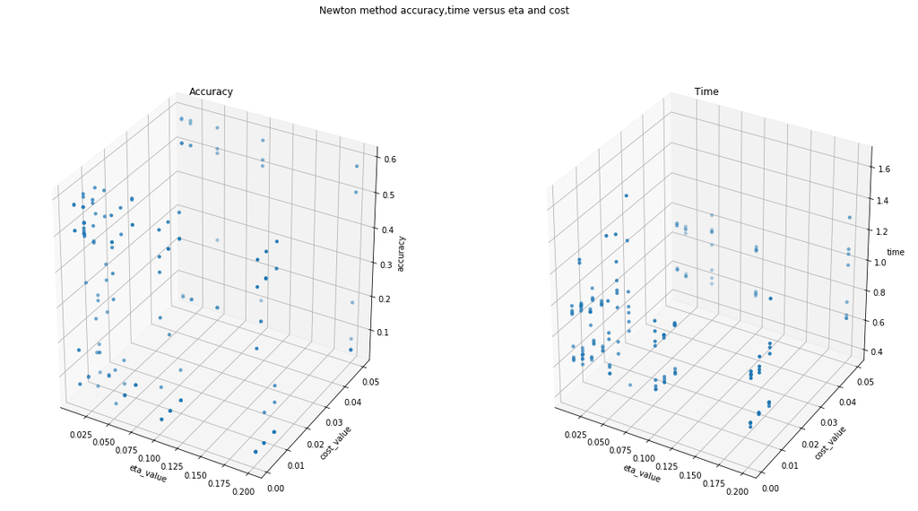

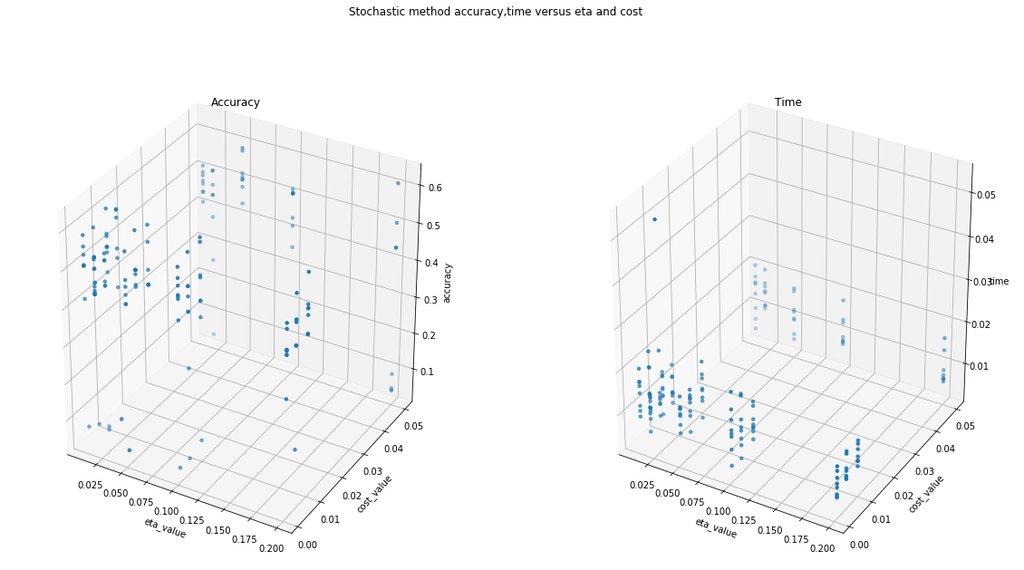

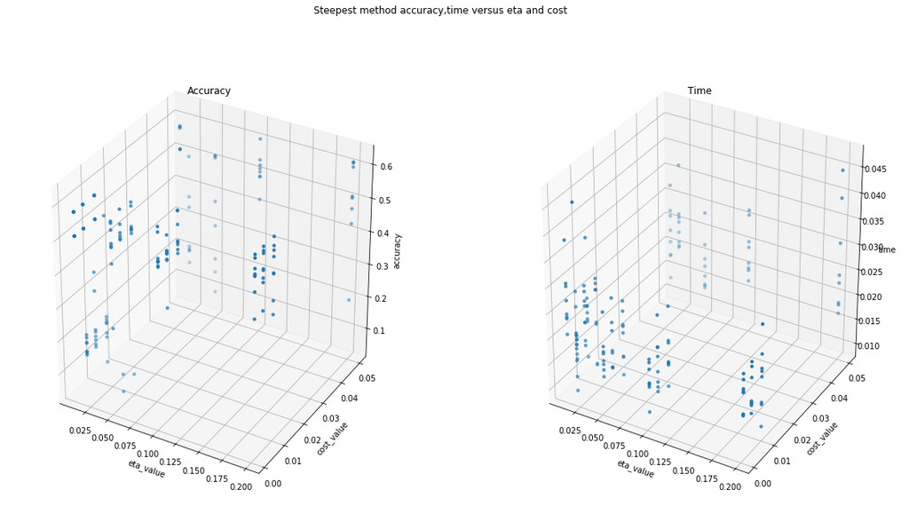

```python
plot_performance(np.array(e_result[slice(160)]),np.array(c_result[slice(160)]),
                 np.array(acc_result[slice(160)]),np.array(time_result[slice(160)]),'Newton')
plot_performance(np.array(e_result[slice(160,320)]),np.array(c_result[slice(160,320)]),
                 np.array(acc_result[slice(160,320)]),np.array(time_result[slice(160,320)]),'Stochastic')
plot_performance(np.array(e_result[slice(320,480)]),np.array(c_result[slice(320,480)]),
                 np.array(acc_result[slice(320,480)]),np.array(time_result[slice(320,480)]),'Steepest')
```

```python
print('The average accuracy is: \t',np.mean(np.array(acc_result)))
print('The standard deviation is: \t',np.std(np.array(acc_result)))
```

```
The average accuracy is: 	 0.39505519779208836
The standard deviation is: 	 0.19302542635838132
```

The average accuracy of our results is poor but the standard deviation is very high. Therefore, we decide to find the maximum accuracy and its corresponding processing time

```python
print('The maximum accuracy is: \t',max(acc_result))
print('The processing time is: \t',time_result[acc_result.index(max(acc_result))])
index=acc_result.index(max(acc_result))
print('Method: ',m_result[index],
      ' Reg: ',r_result[index],
      ' iteration:',20,
      ' Cost: ',c_result[index],
      ' Time: ',time_result[index],' with Accuracy of: ',acc_result[index])
```

```
The maximum accuracy is: 	 0.6145354185832567
The processing time is: 	 0.014409542083740234
Method:  stochastic  Reg:  L1  iteration: 20  Cost:  0.01  Time:  0.014409542083740234  with Accuracy of:  0.6145354185832567
```

That is our top record! We have a data snooping when we train the model. That is foreseeing the result which we should not have seen, and using the result to determine what our optimal choice in different parameters is. We have tried 480 combinations of parameters, which should not be considered justified. That is similar to doing a multiple choice 480 times and using each trial to get the final answer.

### Compare to SciKit Learn

Now we need to compare it with scikit learn.

#### Our model: Advanced Logistic Regression

```python
t=time.time()
alr=AdvancedLogisticRegression(eta=0.05,reg='L1',method='stochastic',iterations=20, C=0.01)
alr.fit(X,y)
yhat = alr.predict(X)
print('time:',(time.time()-t)*1000,'ms, accuracy:',accuracy_score(y,yhat))

print(set(yhat))
```

```
time: 17.1811580657959 ms, accuracy: 0.6034958601655934
{1, 2}
```

#### Scikit Learn

```python
%%time
from sklearn.linear_model import LogisticRegression as SKLogisticRegression

lr_sk = SKLogisticRegression() # all params default

lr_sk.fit(X,y)
print(np.hstack((lr_sk.intercept_[:,np.newaxis],lr_sk.coef_)))
yhat = lr_sk.predict(X)
print('Accuracy of: ',accuracy_score(y,yhat))
print(set(yhat))
```

```
[[-0.14232652 -0.16974752  2.7445143   0.22694054  0.19694636  0.42286732
  -0.03169174 -0.01290729 -0.14317884  0.30999656 -0.49056127 -0.31929443]
 [ 1.49190051  0.0421803   1.52011833  0.1278717  -0.02173425  1.4810363
  -0.02381641  0.02199079  1.47600294  1.46310741 -1.46488918 -0.8750517 ]
 [-1.3685019  -0.01036634 -2.78243485 -0.52848964 -0.0293057  -1.74808543
   0.02913998 -0.01966995 -1.34621301 -1.61432618  1.65142836  0.90860388]]
Accuracy of:  0.7111315547378105
{1, 2}
Wall time: 21.6 ms
```

#### Logistic Regression

```python
%%time
lr = LogisticRegression(0.1,100)
lr.fit(X,y)
print(lr)

yhat = lr.predict(X)
print('Accuracy of: ',accuracy_score(y,yhat))
print('find values: ',set(yhat))
```

```
MultiClass Logistic Regression Object with coefficients:
[[ 2.62372087e-02  8.03276113e-03  9.99601778e-02 -3.17066229e-02
   1.40753047e-01  7.54376018e-03 -1.97918417e-01 -6.56063677e-01
   2.61847307e-02  1.14394518e-01 -6.45186119e-03  1.46055511e-01]
 [-8.17544720e-02 -1.01034754e+00  1.52651660e-01 -1.37478941e-01
  -2.61710671e-01  1.72468521e-02 -3.28285073e+00  9.72107234e-01
  -8.03814530e-02 -2.95524688e-01 -2.25724664e-01 -2.61326953e+00]
 [ 3.38301664e-03  5.76484767e-01 -2.73186759e-01  1.60333111e-01
   7.61979157e-02 -2.74935250e-02  2.38386712e+00 -1.11823987e+00
   2.24679998e-03  5.01892753e-03  1.85341737e-01  1.91984376e+00]]
Accuracy of:  0.5814167433302668
find values:  {1, 2}
Wall time: 48.7 ms
```

Comparing these three results, we find that our advanced logistic regression performs better both in time and accuracy than the logistic regression that was covered in class. Additionally, our training model has the lowest processing time. However, scikit learn has the most accuracy.

[figure not shown]

```python
method=['scikit-learn','logistic regression','advanced logistic regression']
time_compare=[21.6,48.7,4.7]
accuracy_compare=[71,58,61]
# plt.hist(method, time_compare)
# plt.show()
import matplotlib.pyplot as plt

x = [0,1,2]
width = 0.8 # width of the bars

def autolabel(rects):
    # attach some text labels
    for rect in rects:
        height = rect.get_height()
        ax.text(rect.get_x() + rect.get_width()/2., 1.05*height,
                '%d' % int(height),
                ha='center', va='bottom')

fig, ax = plt.subplots(figsize=(12,6))
rects1 = ax.bar(x, time_compare, width, color='b')

ax.set_ylim(0,60)
ax.set_ylabel('Frequency')
ax.set_title('time compare')
ax.set_xticks(np.add(x,(width/2))) # set the position of the x ticks
ax.set_xticklabels(method)


autolabel(rects1)

plt.show()
```

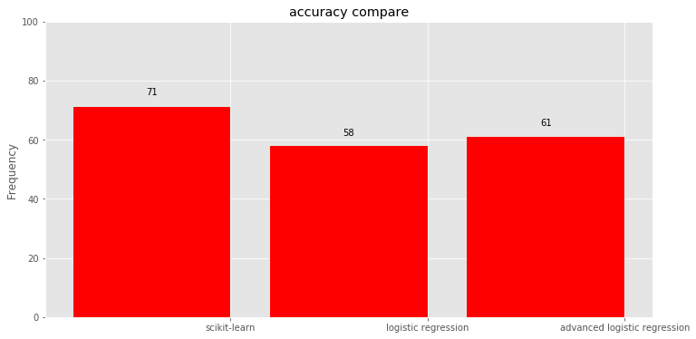

```python
fig, ax = plt.subplots(figsize=(12,6))

rects2 = ax.bar(x, accuracy_compare, width, color='r')

ax.set_ylim(0,100)
ax.set_ylabel('Frequency')
ax.set_title('accuracy compare')
ax.set_xticks(np.add(x,(width/2))) # set the position of the x ticks
ax.set_xticklabels(method)


autolabel(rects2)

plt.show()
```

#### Recommandation

We failed to reach the accuracy of 70% that makes our algorithm useful and scikit-learn reached that accuracy

## Extra

Update the code to use either "one-versus-all" or "one-versus-one" extensions of binary to multi-class classification.

First, we will load the dataset

```python
df = pd.read_csv('data/winequality-red.csv')
df=df.drop_duplicates(subset=None, keep='first', inplace=False)
df=df.reset_index()
# if 'index' in df:
#     del df['index']
def conditions(s):
    if (s['quality']>=6):
        return 2
    elif (s['quality']<=4):
        return 0
    else:
        return 1
df['class']=df.apply(conditions, axis=1)
df.head()
```

|  | index | fixed acidity | volatile acidity | citric acid | residual sugar | chlorides | free sulfur dioxide | total sulfur dioxide | density | pH | sulphates | alcohol | quality | class |
| --- | --- | --- | --- | --- | --- | --- | --- | --- | --- | --- | --- | --- | --- | --- |
| 0 | 0 | 7.4 | 0.70 | 0.00 | 1.9 | 0.076 | 11.0 | 34.0 | 0.9978 | 3.51 | 0.56 | 9.4 | 5 | 1 |
| 1 | 1 | 7.8 | 0.88 | 0.00 | 2.6 | 0.098 | 25.0 | 67.0 | 0.9968 | 3.20 | 0.68 | 9.8 | 5 | 1 |
| 2 | 2 | 7.8 | 0.76 | 0.04 | 2.3 | 0.092 | 15.0 | 54.0 | 0.9970 | 3.26 | 0.65 | 9.8 | 5 | 1 |
| 3 | 3 | 11.2 | 0.28 | 0.56 | 1.9 | 0.075 | 17.0 | 60.0 | 0.9980 | 3.16 | 0.58 | 9.8 | 6 | 2 |
| 4 | 5 | 7.4 | 0.66 | 0.00 | 1.8 | 0.075 | 13.0 | 40.0 | 0.9978 | 3.51 | 0.56 | 9.4 | 5 | 1 |

```python
if 'quality' in df:
    df=df.drop(['quality'],axis=1)
```

Code Below is used to extract rows and make pairs. The index array called index helps us rearrange the result. All the binary logistic regression objects will be stored in the classifiers array for future predict

For one-versus_one, we will first extract rows whose quality include only 0 and 1, then extract rows whose quality 0 and 2, we will use vector binary logistic regression to determine the result and then use the intersection of these two results to get prediction for class 0. Then we will do another vector binary logistic regression training for rows whose quality 1 and 2 and get the overall yhat.

```python
class OvOLogisticRegression:
    def __init__(self, eta, iterations=20):
        self.eta = eta
        self.iters = iterations
        # internally we will store the weights as self.w_ to keep with sklearn conventions

    def __str__(self):
        if(hasattr(self,'w_')):
            return 'MultiClass Logistic Regression Object with coefficients:\n'+ str(self.w_) # is we have trained the object
        else:
            return 'Untrained MultiClass Logistic Regression Object'

    def fit(self,X,y):
        num_samples, num_features = X.shape
        self.unique_ = np.unique(y) # get each unique class value
        num_unique_classes = len(self.unique_)
        self.classifiers_ = [] # will fill this array with binary classifiers

        y_hat=np.empty(len(y))
        for i in range(0,len(y_hat)):
            y_hat[i]=-1
            INDEX=np.array(df['index'])
        for i in range(0,num_unique_classes-1):
            Binary_List=[]
            Target_List=[]
            Index_List=[]
            yhat_list=[]
            result_list=[]
            for j in range(i+1,num_unique_classes,1):

                df_binary1=df[df['class']==self.unique_[i]]
                df_binary2=df[df['class']==self.unique_[j]]
                df_binary=pd.concat([df_binary1,df_binary2])
                target=df_binary['class']==self.unique_[i]
                index=np.array(df_binary['index'])
                Binary_List.append(df_binary)
                Target_List.append(target)
                Index_List.append(index)

            num=len(Binary_List)
            for k in range(0,num):
                blr = VectorBinaryLogisticRegression(self.eta,self.iters)
                blr.fit(Binary_List[k],Target_List[k])
                self.classifiers_.append(blr)


    def predict(self,X):
        num_unique_classes = len(self.unique_)
        y_hat=np.empty(len(X))

        count=0
        for i in range(0,len(y_hat)):
            y_hat[i]=-1
            INDEX=np.array(df['index'])
        for i in range(0,num_unique_classes-1):
            Binary_List=[]
            Index_List=[]
            yhat_list=[]
            result_list=[]
            for j in range(i+1,num_unique_classes,1):
                df_binary1=df[df['class']==self.unique_[i]]
                df_binary2=df[df['class']==self.unique_[j]]
                df_binary=pd.concat([df_binary1,df_binary2])
                index=np.array(df_binary['index'])
                Binary_List.append(df_binary)
                Index_List.append(index)
            num=len(Binary_List)
            for k in range(0,num):
                yhat = self.classifiers_[count].predict(Binary_List[k])
                count+=1
                yhat_list.append(yhat)
                result=[]

                for m in range(0,len(yhat)):
                    if yhat[m]==True:
                        result.append(Index_List[k][m])
                result_list.append(result)

            final_y=result_list[0]

            for n in range(1,len(result_list)):
                final_y=(list(set(final_y).intersection(result_list[n])))
            for v in range(0,len(INDEX)):
                if INDEX[v] in final_y:
                    y_hat[v]=self.unique_[i]


        for i in range(0,len(y_hat)):
            if y_hat[i] ==-1:
                y_hat[i]=2

        return y_hat
```

```python
%%time
OvOlr = OvOLogisticRegression(0.1,100)
OvOlr.fit(df,df['class'])
y_hat=OvOlr.predict(df)
print('Accuracy of: ',accuracy_score(df['class'],y_hat))
print(set(y_hat))
```

```
Accuracy of:  0.5445180279617365
{1.0, 2.0}
Wall time: 251 ms
```

Even binary logistic regression cannot classify the class 0, mainly because class 0 does not have a clear boundary with other classes. The accuracy is lower than logistic regression and much slower than our advanced logistic regression.

## Extra II

```python
%%time
from numpy.linalg import pinv
class HessianBinaryLogisticRegression(BinaryLogisticRegression):

    # overwrite gradient function
    def _get_gradient(self,X,y):

        g = self.predict_proba(X,add_bias=False).ravel()
        hessian = X.T @ np.diag(g*(1-g)*(y - 2*y*g + 2*g + 3*g**2)) @ X # calculate the hessian

        ydiff = (y-g)*g*(1-g)
        gradient = np.sum(X * ydiff[:,np.newaxis], axis=0)
        gradient = gradient.reshape(self.w_.shape)

        return pinv(hessian) @ gradient



# training
X = X_train
y = (y_train>1).astype(np.int)


# use hessian logistic regression to train
num_of_iterations = 1
hlr = HessianBinaryLogisticRegression(eta=0.1,iterations=num_of_iterations)

hlr.fit(X,y)
yhat = hlr.predict(X)
print('Training Accuracy: ',accuracy_score(y,yhat))

# test data
X = X_test
y = (y_test>1).astype(np.int)
yhat = hlr.predict(X)
print('Testing Accuracy: ',accuracy_score(y,yhat))
```

```
Training Accuracy:  0.7562097516099356
Testing Accuracy:  0.7132352941176471
Wall time: 14 ms
```

In this part, we overwrite a function and calculate the hessian to get gradient. And then train the classfier and get the train accuracy and test accuracy. The hessian calculation use MSE(Mean squared error) function to get the answer. And in the code block we implement it for get gradient function

**reference from: https://en.wikipedia.org/wiki/Mean_squared_error**

As it shows that both time and accuracy are improved